# Delta AUC Nested Model – Complete Analysis

Yuxuan Liu

2026-03-15

# 1 Setup

## 1.1 Load Packages

```r
# Determine project root (works in both RStudio and command-line knit)
script_dir <- tryCatch(
  dirname(rstudioapi::getActiveDocumentContext()$path),
  error = function(e) NULL
)
if (is.null(script_dir) || script_dir == "") {
  # When knitting from command line, knitr sets the working directory to
  # the directory containing the Rmd file.
  script_dir <- getwd()
}
cat("Project directory:", script_dir, "\n")
```

```
## Project directory: /Users/yuxuanliu/Desktop/Classification ROC, Statistical Tests and Cross Validation/debiased_auc_inference
```

```r
source(file.path(script_dir, "R", "00_packages.R"))
```

```
## All packages loaded.
```

## 1.2 Load Function Modules

```r
source(file.path(script_dir, "R", "01_model_functions.R"))
source(file.path(script_dir, "R", "02_ground_truth.R"))
source(file.path(script_dir, "R", "03_simulation_RxB.R"))
source(file.path(script_dir, "R", "04_inference_viz.R"))
source(file.path(script_dir, "R", "05_loo_cv.R"))
source(file.path(script_dir, "R", "06_real_data_ptb.R"))
source(file.path(script_dir, "R", "07_real_data_heart.R"))
```

## 1.3 Simulation Parameters

> **Note:** All simulation sizes (R, B, n) are kept deliberately small so this document renders in a few minutes. For production-quality results, increase `R` to 10 000 for ground truth, `R=50, B=20` for R×B simulation, and restore the full sample sizes (n=2000) – see `demo_run_all.R` for the original values.

```r
p   <- 100   # number of noise features
mu  <- 1     # signal mean shift
sig <- 10    # noise SD
snr <- (mu - 0)^2 / sig^2
cat(sprintf("Signal-to-Noise Ratio (SNR) = %.4f\n", snr))
```

```
## Signal-to-Noise Ratio (SNR) = 0.0100
```

# 2 Ground Truth

We estimate the true $\Delta$AUC (full − reduced) via large-scale Monte Carlo with independent training and test sets.

## 2.1 Setting 1: $n_{train} = 500$, $n_{test} = 1000$

```r
# NOTE: R kept small for demo speed. Increase R for production runs.
ground_truth_1 <- compute_ground_truth(
  n1 = 250, n2 = 250,
  n1_test = 500, n2_test = 500,
  R = 100,
  p = p, mu = mu, sig = sig,
  model_types = c("lda", "logistic")
)
```

```r
cat("Ground truth setting 1 (n_train=500, n_test=1000):\n")
```

```
## Ground truth setting 1 (n_train=500, n_test=1000):
```

```r
print(ground_truth_1$ground_truth)
```

```
##      delta_auc_lda delta_auc_logistic
##        -0.04747824        -0.05504796
```

## 2.2 Setting 2: $n_{train} = 400$, $n_{test} = 1000$

```r
ground_truth_2 <- compute_ground_truth(
  n1 = 200, n2 = 200,
  n1_test = 500, n2_test = 500,
  R = 100,
  p = p, mu = mu, sig = sig,
  model_types = c("lda", "logistic")
)
```

```r
cat("Ground truth setting 2 (n_train=400, n_test=1000):\n")
```

```
## Ground truth setting 2 (n_train=400, n_test=1000):
```

```r
print(ground_truth_2$ground_truth)
```

```
##      delta_auc_lda delta_auc_logistic
##        -0.05704304        -0.07406660
```

# 3 R × B Simulation

Non-split model is fit **once** per Monte Carlo replicate (deterministic on same data). Only the sample-split evaluation is repeated B times. A single iteration is timed first so you can tune R and B.

```r
# NOTE: R, B kept small for demo speed. Increase for production.
sim_result <- run_simulation_RxB(
  n1 = 250, n2 = 250,
  R  = 10, B = 10,
  p  = p, mu = mu, sig = sig,
  test_frac   = 0.25,
  model_types = c("lda", "logistic"),
  nrounds     = 100,
  reduced_formula = "Y ~ X1"
)
```

```
## Timing a single (i=1, j=1) iteration...
##   Single iteration: 0.13 sec
##   Estimated total (R=10, B=10): 13.0 sec (0.2 min)
##   MC replicate 1 / 10
##   MC replicate 2 / 10
##   MC replicate 3 / 10
##   MC replicate 4 / 10
##   MC replicate 5 / 10
##   MC replicate 6 / 10
##   MC replicate 7 / 10
##   MC replicate 8 / 10
##   MC replicate 9 / 10
##   MC replicate 10 / 10
## Simulation completed in 13.7 sec (0.2 min).
```

```r
cat(sprintf("Single iteration time : %.2f sec\n", sim_result$time_single))
```

```
## Single iteration time : 0.13 sec
```

```r
cat(sprintf("Total simulation time : %.1f sec (%.1f min)\n",
            sim_result$time_total, sim_result$time_total / 60))
```

```
## Total simulation time : 13.7 sec (0.2 min)
```

# 4 Inference & Visualization

Inference is computed over all **R × B** split samples (pooled). Coverage rates are computed against ground truth setting 1.

```r
inference <- compute_inference(sim_result,
                               ground_truth = ground_truth_1$ground_truth)
print_inference_summary(inference)
```

```
##
## ====== Inference Summary (R*B pooled) ======
##
## --- LDA ---
##   Non-split  : mean=0.06324  sd=0.01110  z=5.698
##   Non-split DeLong CI: [0.04160, 0.08489]
##   Split (pooled 100) : mean=0.00149  sd=0.03564  z=0.042
##   Split pooled CI : [-0.07094, 0.06788]
##   Split DeLong CI (mean): [-0.06188, 0.06485]
##   Coverage (boot split)   : 0.400
##   Coverage (DeLong split) : 0.630
##   Coverage (DeLong nosplit): 0.000
##
## --- LOGISTIC ---
##   Non-split  : mean=0.06997  sd=0.01221  z=5.729
##   Non-split DeLong CI: [0.04741, 0.09253]
##   Split (pooled 100) : mean=-0.03989  sd=0.04604  z=-0.866
##   Split pooled CI : [-0.12679, 0.04181]
##   Split DeLong CI (mean): [-0.11908, 0.03930]
##   Coverage (boot split)   : 0.900
##   Coverage (DeLong split) : 0.890
##   Coverage (DeLong nosplit): 0.000
```

## 4.1 AUC Difference Histograms

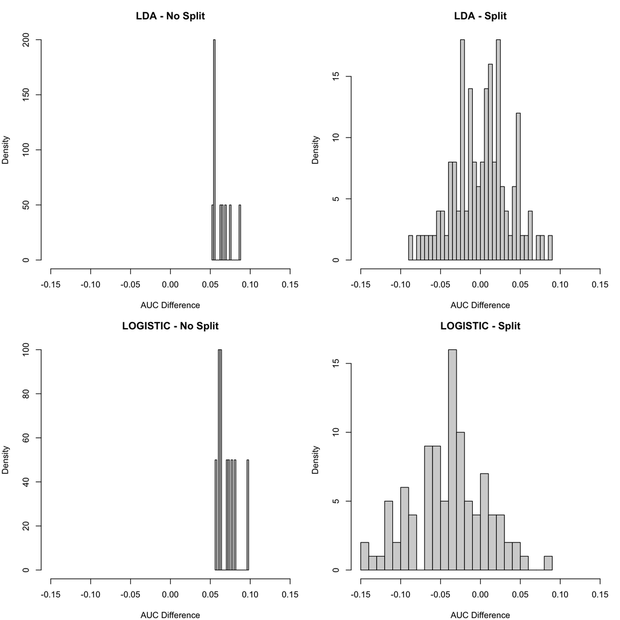

```r
plot_auc_histograms(sim_result, xlim_range = c(-0.15, 0.15))
```

# 5 Leave-One-Out Cross Validation

LOO-CV simulation for LDA and Logistic regression. Each Monte Carlo replicate generates fresh data; non-split and LOO results are both deterministic for a given dataset.

```r
# NOTE: R kept small for demo. LOO-CV is expensive (refits per observation).
loo_result <- run_loo_cv_simulation(
  n1 = 100, n2 = 100,
  R  = 3,
  p  = p, mu = mu, sig = sig,
  reduced_formula = "Y ~ X1"
)
```

```
##   LOO-CV: replicate 1 / 3
##   LOO-CV: replicate 2 / 3
##   LOO-CV: replicate 3 / 3
## LOO-CV simulation done in 33.5 sec.
```

```r
print_loo_summary(loo_result)
```

```
##
## --- LDA ---
##   Non-split:
##     mean(full)=0.99120  sd=0.00151  mean(redu)=0.89293  sd=0.03141
##     mean(diff)=0.09827  sd=0.03113  z=3.156
##   LOO-CV:
##     mean(full)=0.76393  sd=0.00847  mean(redu)=0.89050  sd=0.03195
##     mean(diff)=-0.12657  sd=0.03931  z=-3.220
##   DeLong CI (nosplit mean):
##     [0.05882, 0.13771]
##   DeLong CI (LOO mean):
##     [-0.18667, -0.06646]
##
## --- LOGISTIC ---
##   Non-split:
##     mean(full)=1.00000  sd=0.00000  mean(redu)=0.89293  sd=0.03141
##     mean(diff)=0.10707  sd=0.03141  z=3.408
##   LOO-CV:
##     mean(full)=0.68760  sd=0.01700  mean(redu)=0.88840  sd=0.03267
##     mean(diff)=-0.20080  sd=0.04790  z=-4.192
##   DeLong CI (nosplit mean):
##     [0.06635, 0.14778]
##   DeLong CI (LOO mean):
##     [-0.26802, -0.13358]
```

## 5.1 LOO-CV Histograms

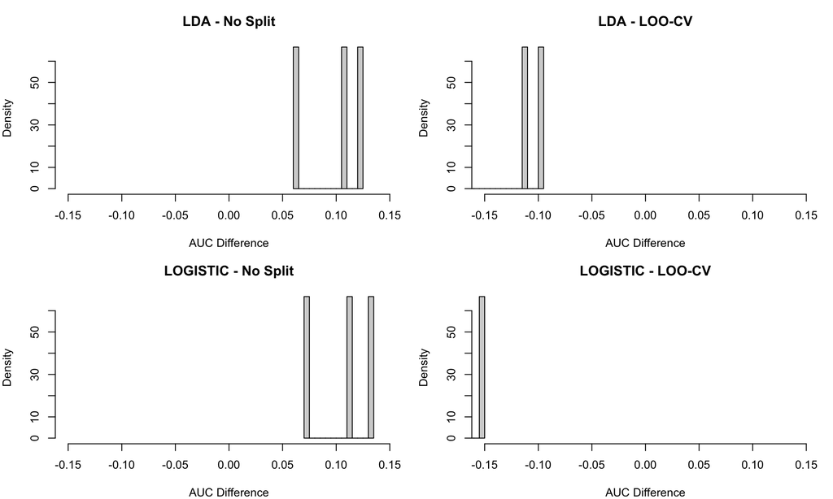

```r
plot_loo_histograms(loo_result)
```

# 6 Real Data Application – Preterm Birth

Uses the `ptb` dataset from the **SELR** package.

- **Scenario 1**: Full model (all features + interactions) vs reduced model.
- **Scenario 2**: HC-only features vs base model.

Non-split results are computed once; split results repeated R times.

```r
if (exists("ptb")) {
  ptb_result <- run_ptb_analysis(
    R = 50,
    model_types = c("lda", "logistic"),
    nrounds = 100
  )
} else {
  cat("PTB dataset not found. Skipping.\n")
  cat("Make sure the SELR package is installed and loaded.\n")
  ptb_result <- NULL
}
```

```
##
## === PTB Scenario: Full interactions vs reduced ===
##   Non-split done.
##   Split rep 10 / 50
##   Split rep 20 / 50
##   Split rep 30 / 50
##   Split rep 40 / 50
##   Split rep 50 / 50
##
## === PTB Scenario: HC-only vs base ===
##   Non-split done.
##   Split rep 10 / 50
##   Split rep 20 / 50
##   Split rep 30 / 50
##   Split rep 40 / 50
##   Split rep 50 / 50
```

```r
if (!is.null(ptb_result)) {
  print_ptb_summary(ptb_result)
}
```

```
##
## ====== PTB scenario1 ======
##
## --- LDA ---
##   Non-split: AUC_full=0.8219  AUC_redu=0.7230  diff=0.0989
##   DeLong CI: [0.0409, 0.1570]
##   Split: mean(full)=0.6313 sd=0.0841  mean(redu)=0.7109 sd=0.0684
##   Split diff: mean=-0.0796 sd=0.0849 z=-0.937
##   Split 90% CI: [-0.2263, 0.0380]
##   DeLong CI (split mean): [-0.2401, 0.0810]
##
## --- LOGISTIC ---
##   Non-split: AUC_full=0.8483  AUC_redu=0.7351  diff=0.1132
##   DeLong CI: [0.0451, 0.1813]
##   Split: mean(full)=0.5871 sd=0.0839  mean(redu)=0.7101 sd=0.0650
##   Split diff: mean=-0.1230 sd=0.0828 z=-1.485
##   Split 90% CI: [-0.2477, -0.0003]
##   DeLong CI (split mean): [-0.2996, 0.0537]
##
## ====== PTB scenario2 ======
##
## --- LDA ---
##   Non-split: AUC_full=0.6899  AUC_redu=0.4962  diff=0.1937
##   DeLong CI: [0.0470, 0.3404]
##   Split: mean(full)=0.6453 sd=0.0715  mean(redu)=0.5060 sd=0.0830
##   Split diff: mean=0.1394 sd=0.1244 z=1.120
##   Split 90% CI: [-0.0562, 0.3087]
##   DeLong CI (split mean): [-0.1791, 0.4578]
##
## --- LOGISTIC ---
##   Non-split: AUC_full=0.6970  AUC_redu=0.4962  diff=0.2008
##   DeLong CI: [0.0592, 0.3423]
##   Split: mean(full)=0.6545 sd=0.0651  mean(redu)=0.4336 sd=0.0492
##   Split diff: mean=0.2209 sd=0.0729 z=3.029
##   Split 90% CI: [0.1217, 0.3510]
##   DeLong CI (split mean): [-0.0621, 0.5040]
```

# 7 Real Data Application – Framingham Heart Study

Uses the `framingham` dataset from the **riskCommunicator** package.

- Full model: `Y ~ BMI + SYSBP + DIABP + TOTCHOL + AGE`
- Reduced model: `Y ~ BMI + SYSBP + DIABP + TOTCHOL` (drops AGE)

```r
if (exists("framingham")) {
  heart_result <- run_heart_analysis(R = 50)
} else {
  cat("Framingham dataset not found. Skipping.\n")
  cat("Make sure the riskCommunicator package is installed and loaded.\n")
  heart_result <- NULL
}
```

```
## Max visits per participant: 1
## Non-split done.
##   Heart split rep 10 / 50
##   Heart split rep 20 / 50
##   Heart split rep 30 / 50
##   Heart split rep 40 / 50
##   Heart split rep 50 / 50
```

```r
if (!is.null(heart_result)) {
  print_heart_summary(heart_result)
}
```

```
##
## ====== Framingham Heart Study Results ======
##
## --- LDA ---
##   Non-split: AUC_full=0.6915  AUC_redu=0.6846  diff=0.0069
##   DeLong CI: [0.0014, 0.0124]
##   Split: mean(full)=0.6708 sd=0.0238  mean(redu)=0.6691 sd=0.0223
##   Split diff: mean=0.0017 sd=0.0068 z=0.253
##   Split 90% CI: [-0.0143, 0.0085]
##   DeLong CI (split mean): [-0.0071, 0.0106]
##
## --- LOGISTIC ---
##   Non-split: AUC_full=0.6937  AUC_redu=0.6847  diff=0.0090
##   DeLong CI: [0.0006, 0.0175]
##   Split: mean(full)=0.6708 sd=0.0233  mean(redu)=0.6673 sd=0.0221
##   Split diff: mean=0.0035 sd=0.0079 z=0.445
##   Split 90% CI: [-0.0150, 0.0117]
##   DeLong CI (split mean): [-0.0090, 0.0160]
```

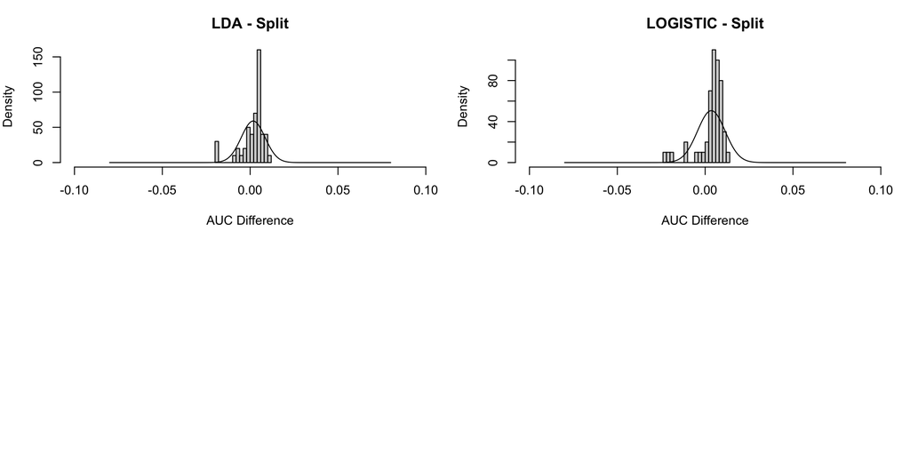